# P4: Exploring Individual Contributions to Campaign Committees of 2016 Presidential Candidates: Trump, and Clinton

# Intro

In this project, I’ll be examining 2016 presidential campaign finance data. specifically, I’ll be looking at individual contributions made to two party nominees’ campaign committee, Hillary for America, and Trump for President.

Once packages and data are loaded, I Add a rowID column to dataset. Note that ContribID is unique to each person (contributor), but anyone could make multiple donations, I need to have a rowID for each unique transaction.

## Structure of dataset

The following is the structure of the dataset. Take a look at few rows:

```
##           candname            campaign   ContribID State   zip       date
## 1 Clinton, Hillary Hillary for America p0004889134    OH 45236 2016-10-19
## 2 Clinton, Hillary Hillary for America p0003315981    AR 72216 2016-10-19
## 3 Clinton, Hillary Hillary for America h3001379681    TX 76132 2016-10-19
## 4 Clinton, Hillary Hillary for America p0004896907    MN 55107 2016-10-19
## 5 Clinton, Hillary Hillary for America p0002867786    FL 33334 2016-10-19
## 6 Clinton, Hillary Hillary for America p0003321685    OR 97352 2016-10-19
##   amount gender rowID
## 1     91      M     1
## 2    150      M     2
## 3     50      F     3
## 4    500      F     4
## 5     50      F     5
## 6     25      F     6
```

Here’s a summary statistics:

```
##              candname                               campaign
##  Clinton, Hillary:2494371   Donald J Trump For President: 386241
##  Trump, Donald   : 386241   Hillary for America         :2494371
##
##
##
##
##
##        ContribID           State              zip
##  p0004665299:   1520   CA     : 529356   10025  :   9175
##  p0002933786:   1099   NY     : 302283   10024  :   8862
##  p0004187302:    637   TX     : 183863   10023  :   8731
##  p0003179541:    597   FL     : 170946   10011  :   8606
##  m0001364878:    367   MA     : 113927   11201  :   7591
##  p0002855911:    354   PA     : 101007   20009  :   7438
##  (Other)    :2876038   (Other):1479230   (Other):2830209
##       date                amount         gender          rowID
##  Min.   :2015-04-07   Min.   :-84236.0   f:      2   Min.   :      1
##  1st Qu.:2016-06-22   1st Qu.:    16.0   F:1631720   1st Qu.: 720154
##  Median :2016-08-01   Median :    30.0   I:      6   Median :1440307
##  Mean   :2016-07-19   Mean   :   152.2   m:     10   Mean   :1440307
##  3rd Qu.:2016-09-21   3rd Qu.:   100.0   M:1154432   3rd Qu.:2160459
##  Max.   :2016-10-19   Max.   : 86936.0   N:  33455   Max.   :2880612
##                                          U:  60987
```

Notes: The ContribId p0004665299 is definitely an outlier. Donating 1520 times, each time $1 is unrealistic/unimportant. This project examines donations from 2015-04-07 to 2016-10-19. A negative amount indicates a refund, and is beyond the scope of this study. Therefore, they will not be considered. The only values we care about in the gender column are F (Female) and M (Male).

The following dataframe is grouped_by_contrib, a dataset that groups transactions by contributors (represented by unique ContribIDs). So we get the total amount each person has contributed as well as number of contributions s/he’s made.

total = total amount of money someone donated. n = number of donations

```
## # A tibble: 6 × 3
##     ContribID total     n
##        <fctr> <int> <int>
## 1 a0000030955  2700     1
## 2 a0000038835  1200     2
## 3 a0000054561  2700     1
## 4 a0000057235  1500     1
## 5 a0000063631  8100     3
## 6 a0000063670 10800     4
```

```
##        ContribID          total               n
##  a0000030955:     1   Min.   :    1.0   Min.   :   1.000
##  a0000038835:     1   1st Qu.:   50.0   1st Qu.:   1.000
##  a0000054561:     1   Median :  200.0   Median :   1.000
##  a0000057235:     1   Mean   :  573.9   Mean   :   3.702
##  a0000063631:     1   3rd Qu.:  500.0   3rd Qu.:   3.000
##  a0000063670:     1   Max.   :86936.0   Max.   :1520.000
##  (Other)    :772869
```

# Exploring Univariate and Bivariate Variables

It’d be interesting to see how variables like total amount, gender, zip, etc. are distributed. So, I’ll start with plotting histograms.

#### 1. histogram of total contributions

Since individual donation limit per election is $2700 I limited the x axis. First, let’s take a look at the sample as it takes less time to compile. Note: This dataset is not aggregated over contributors, so it’s just showing distribution of amount.

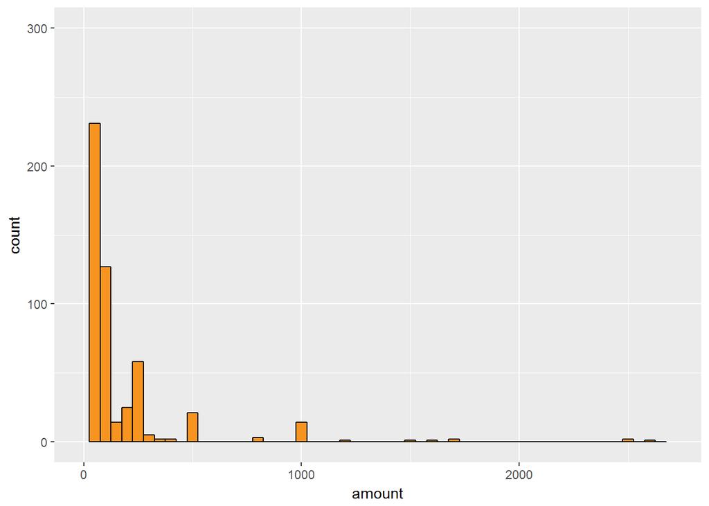

Now, let’s take a look at our aggregated dataset where each row represents a unique contributor.

```
##    Min. 1st Qu.  Median    Mean 3rd Qu.    Max.
##     1.0    50.0   200.0   573.9   500.0 86940.0
```

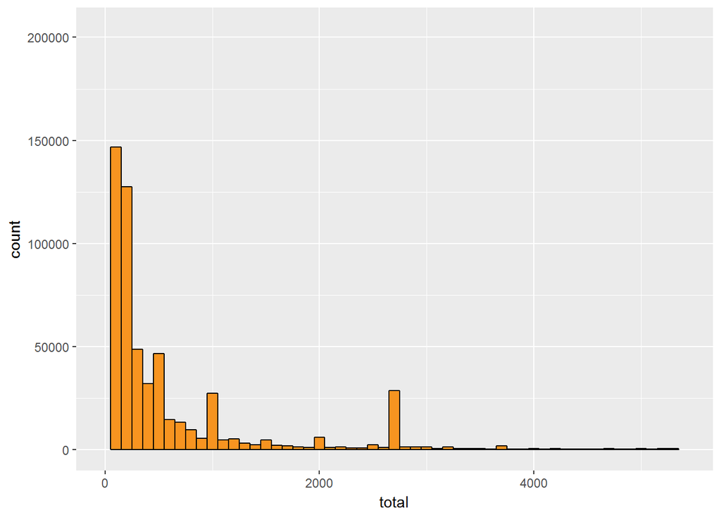

zoom into the range 0-500 (since median is 200, and 3rd Qu is 500)

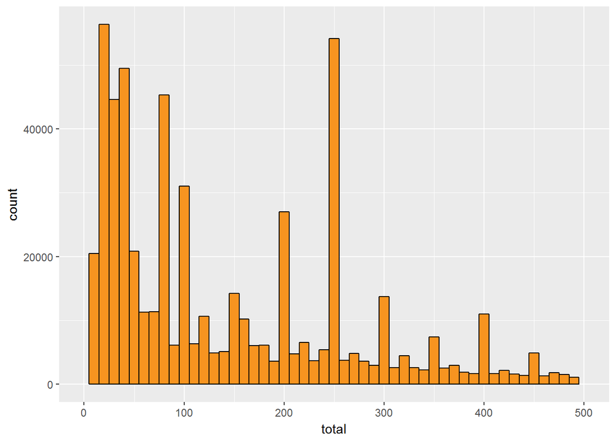

#### 2. Histogram of contribution count

In this section, I look at how the count of donations for individuals is distributed using Contrib.by_ContribID dataset created earlier, let’s look at the number of donations of each individual

```
##     Min.  1st Qu.   Median     Mean  3rd Qu.     Max.
##    1.000    1.000    1.000    3.702    3.000 1520.000
```

plot: set the xlim to get rid of the $1520 outlier

n: count of donations per person.

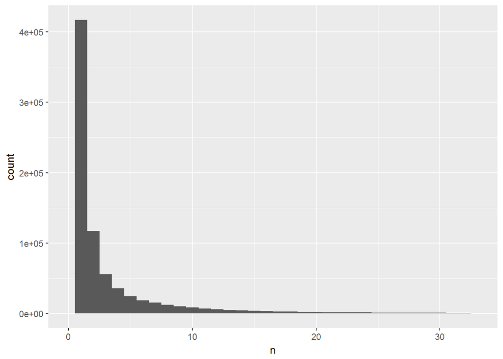

observation 1: mean is pulled by the outliers. max of 1520 is definitely an outlier observation 2: data is right skewed because the mean is far away from median. observation 3: someone donated $1 amount for 1520 times! observation 4: most people had 1-5 contributions.

#### 3. Total donations trend

Maybe it makes more sense to look at the total amount of donations/day rather than number of donations/day, because we eventually care about the money spent.

The first step is to group the donations by date. Then, I add a new column called don_month which contains the month of donation.

I’d expect to see an exponential histogram because candidates recieve more donations as it gets closer to the election day.

```
## # A tibble: 6 × 3
##         date   total     n
##       <date>   <int> <int>
## 1 2015-04-07   18900     7
## 2 2015-04-10    2700     1
## 3 2015-04-11       6     2
## 4 2015-04-12 1416914  2594
## 5 2015-04-13 1073015  1298
## 6 2015-04-14  880271   707
```

where n is number of donations per day, and total is the sum of donations per day. Here’s a bar chart of daily total donations.

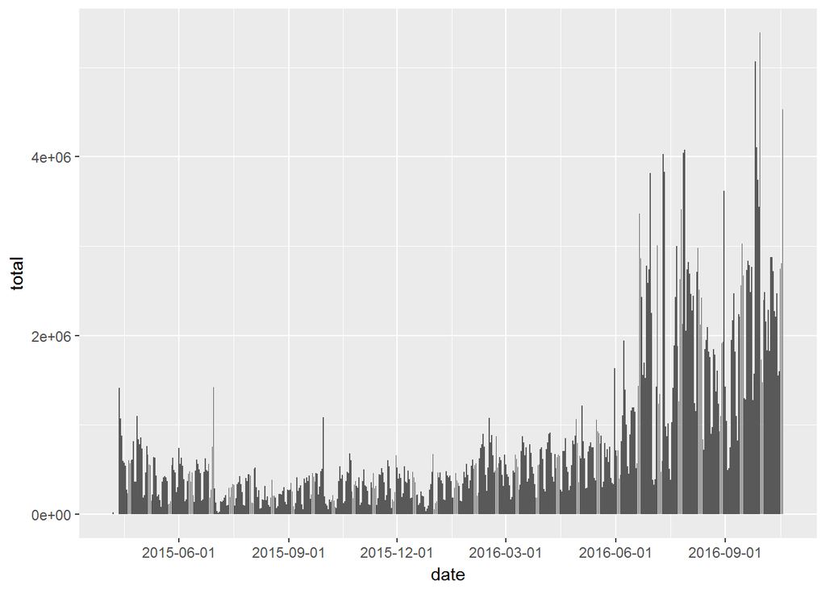

Too noisy. Let’s try a bar chart with a better aggregation:

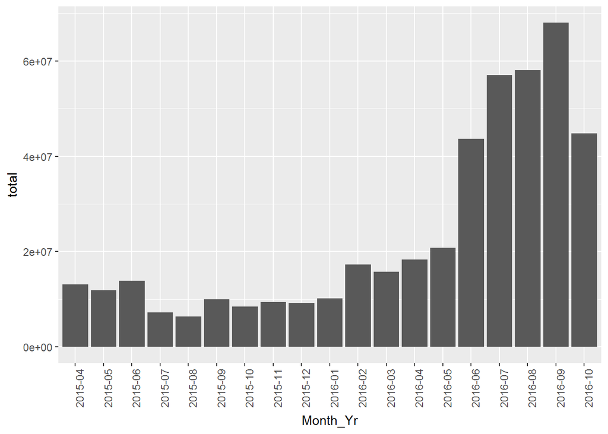

#### 4. Total donations VS State

The goal here is to compare top 10 states with highest total donations.

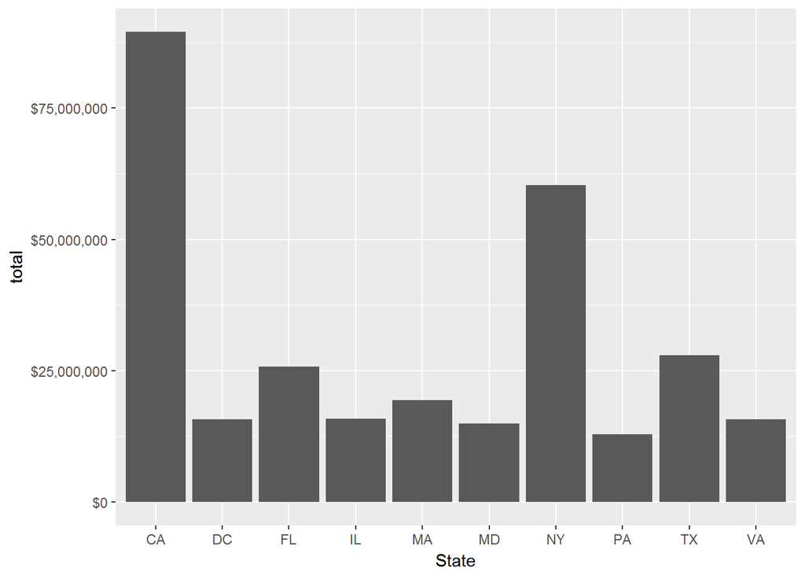

I’m not surprised to see CA and NY as top spending states. IL is interestingly on the list.

#### 5. Total Donations VS Zip

Here’s a bar chart showing 20 zip codes with highest individual contributions.

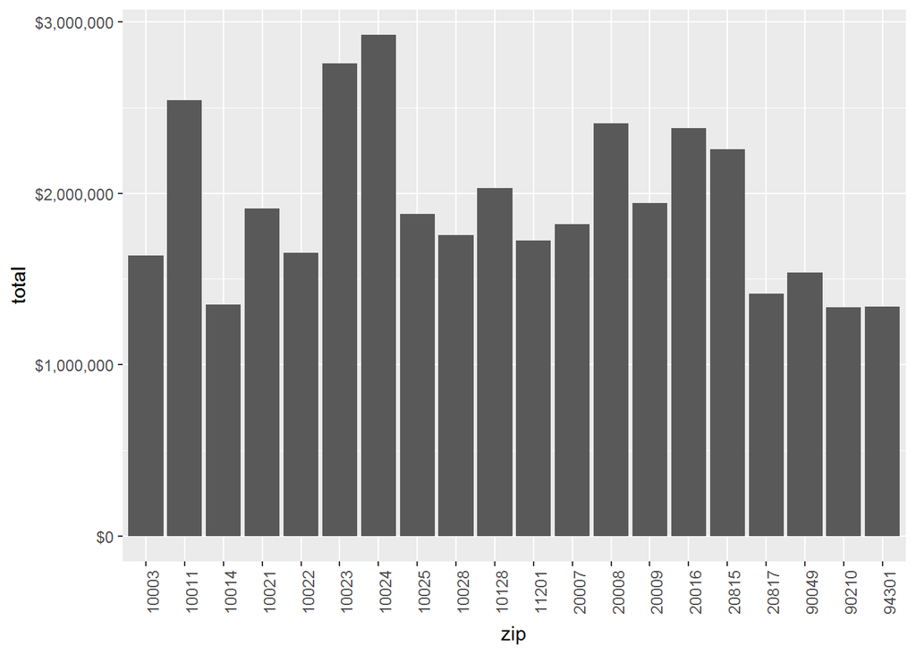

#### 6. Comparing Trump and Clinton numbers based on contributors’ gender

Next, let’s break the data down based on gender. This is important, particularly because Hillary’s campaign was mainly built around gender equality. I’d assume more women supported Hillary as they wanted to support a woman so their voice can be better heard.

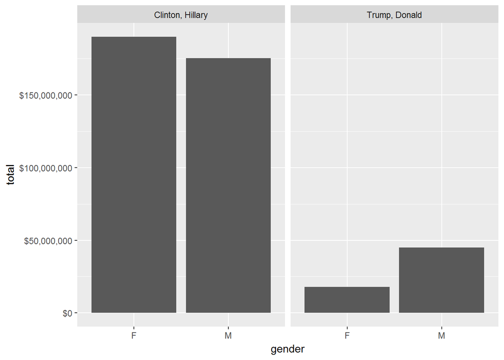

Obviously, Clinton raised way more money than Trump did, and that regardless of gender. Here’s my main takeaway: proportion of female to male contributors is way higher for Hillary than it is for Trump.

# Multivariate Plots Section

Based on prevoius findings, I’d like to learn more about:

1- How the number of donations is related to the amount of donation for each unique donor? 2- Total donation trends over time based on gender 3- Total donation trends over time based on candidates 4- Number of donation trends over time based on gender 5- Number of donation trends over time based on candidates

1- To answer the first question, I need to create the appropriate data-set.

```
## Source: local data frame [6 x 5]
## Groups: ContribID, gender [6]
##
##     ContribID gender         candname total     n
##        <fctr> <fctr>           <fctr> <int> <int>
## 1 a0000030955      F    Trump, Donald  2700     1
## 2 a0000038835      F    Trump, Donald  1200     2
## 3 a0000054561      M Clinton, Hillary  2700     1
## 4 a0000057235      M Clinton, Hillary  1500     1
## 5 a0000063631      F Clinton, Hillary  2700     1
## 6 a0000063631      M Clinton, Hillary  5400     2
```

Now, let’s take a look at total amount VS count of donations for each contributors.

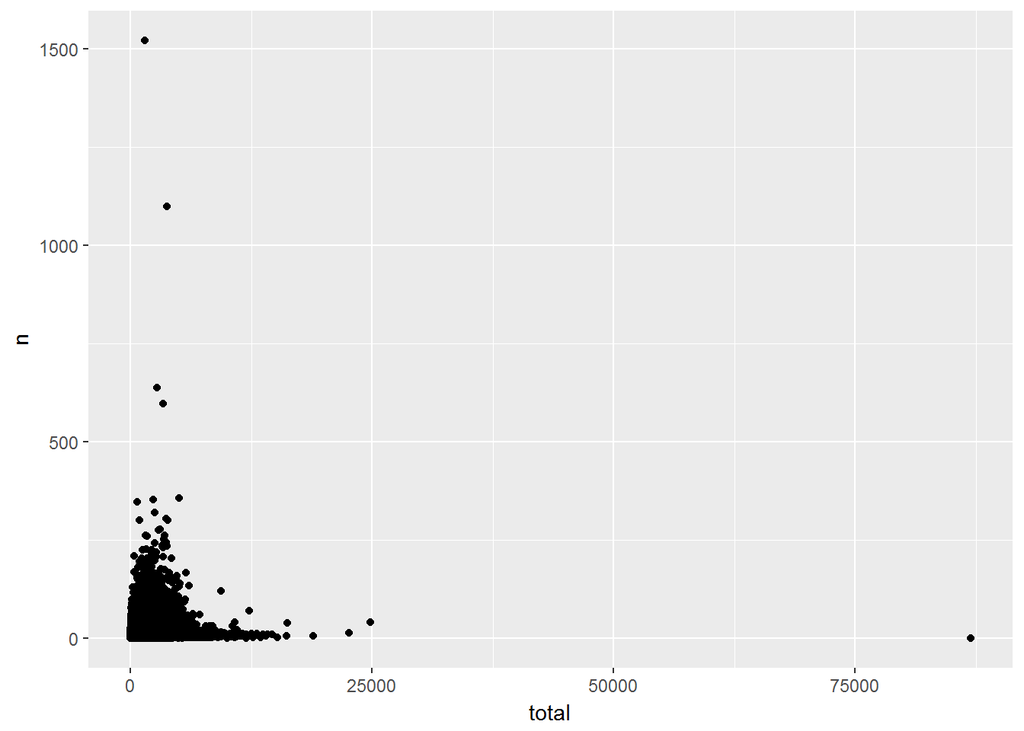

Getting rid of outliers, adjusting axes, using alpha, etc. Here’s the result:

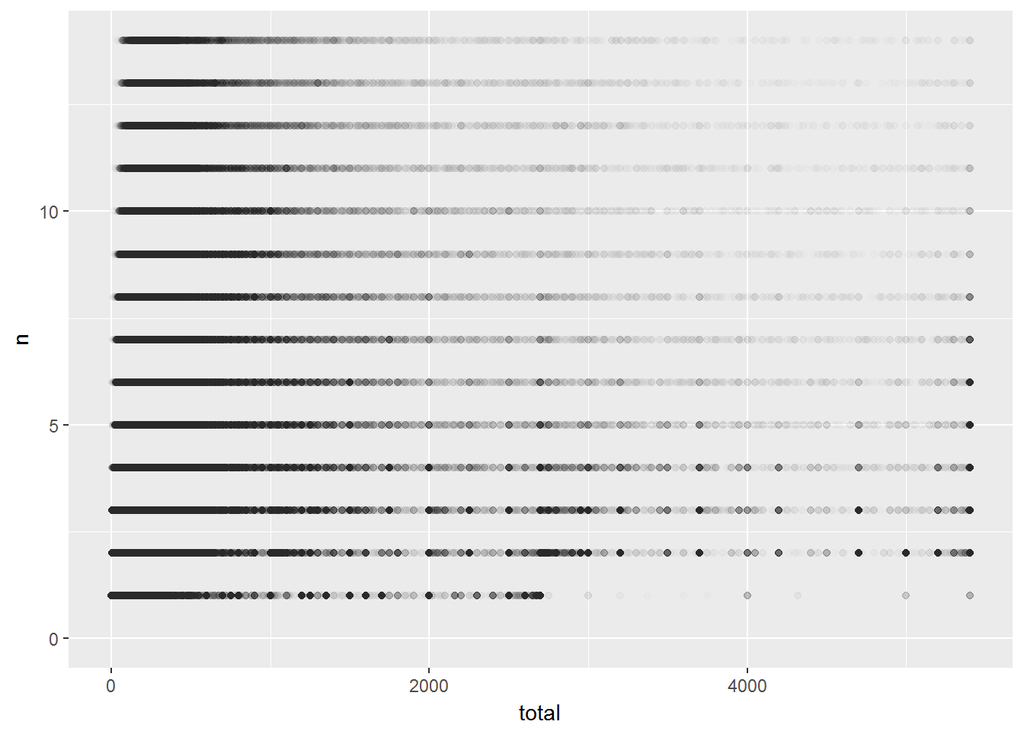

Interesting! We can see that as the total increases, the number of uniques contributors decrease. Also, as the number of donations increase, the number of high donation contributors decrease.

2- Similar to the previous question, we first need to create the aggregated dataset. This time, aggregated by date instead of ContribID.

We can see the trend in total donations daily, broken down based on gender.

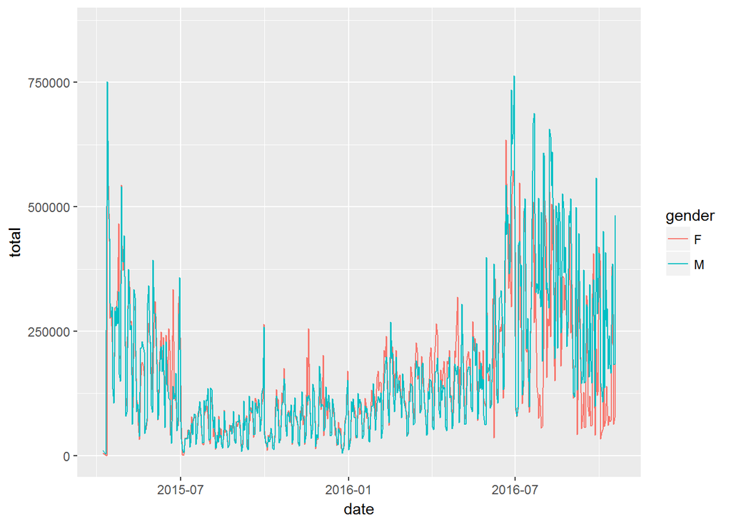

It’s hard to compare M to F in this graph, but as you can see overall they both decrease and increase again.

3- Similar to previous step, this time we need to take into acount the recipient of the donation

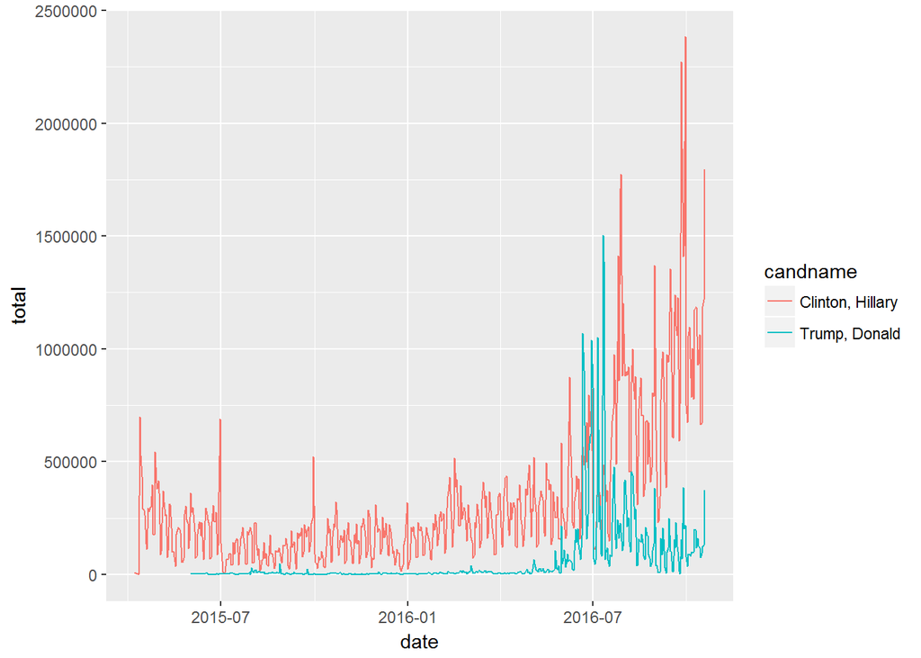

It looks like we need to change the y scale to log. Also, need to add smooth line

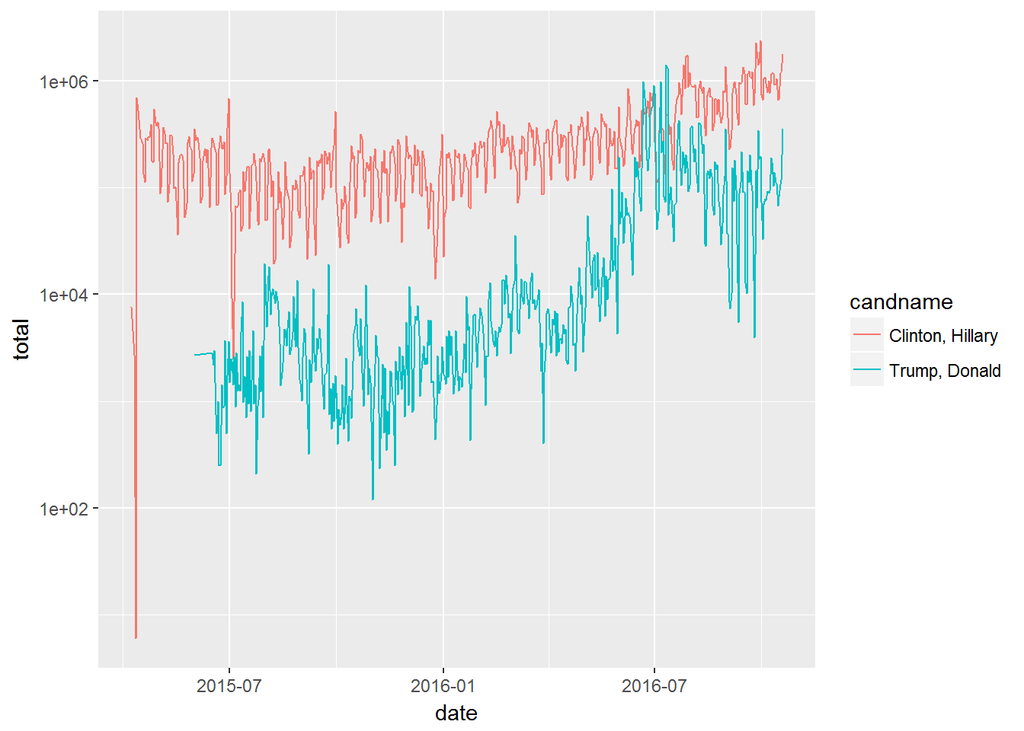

Seems like Clinton was almost always heads and shoulders higher than Trump. However, there’s a big spike for Trump around June, 2016.

4- Use count of donations (aggregated per day) instead of sum of donations

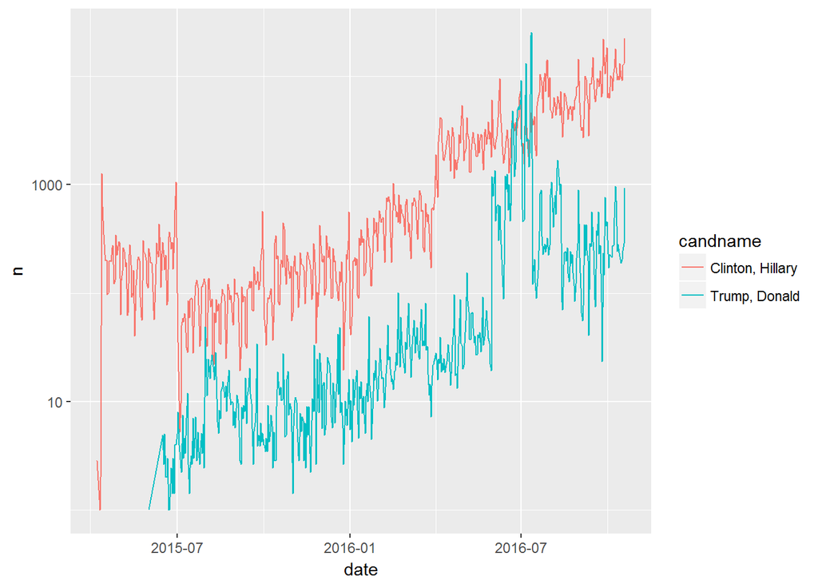

5- Looking at count of donations over time, based on gender

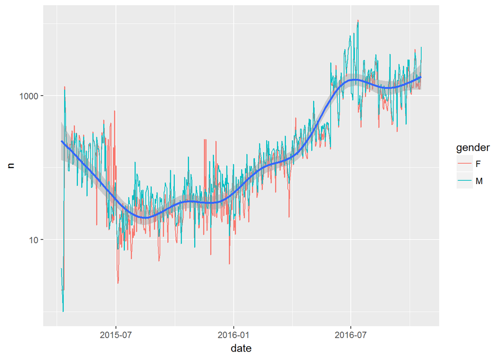

Let’s look at count vs. amount based on candidates:

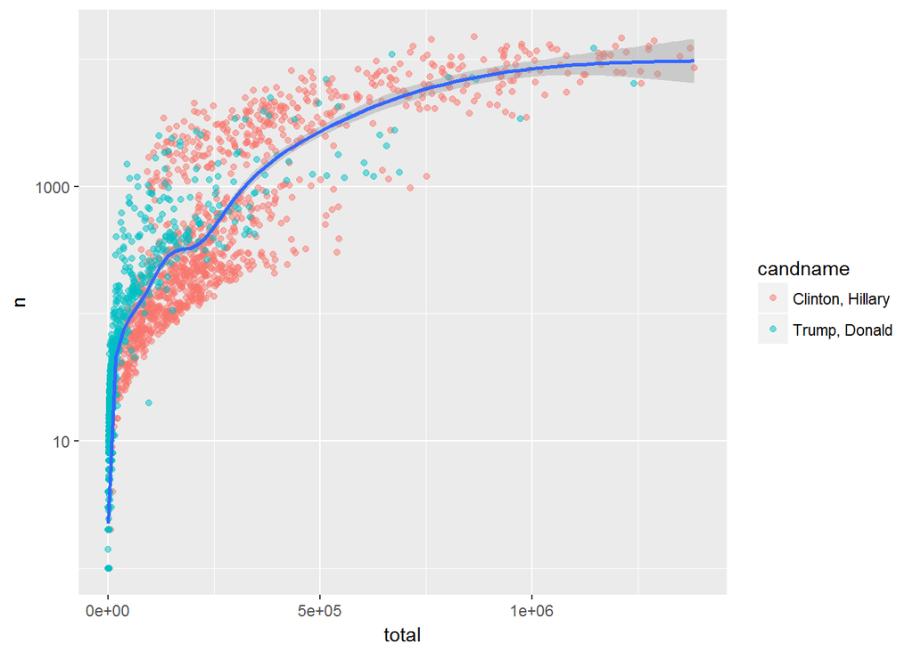

My final curiosity for this part is to see if donors of a particular candidate have different trends based on gender. I’ll be looking at both count, and amount:

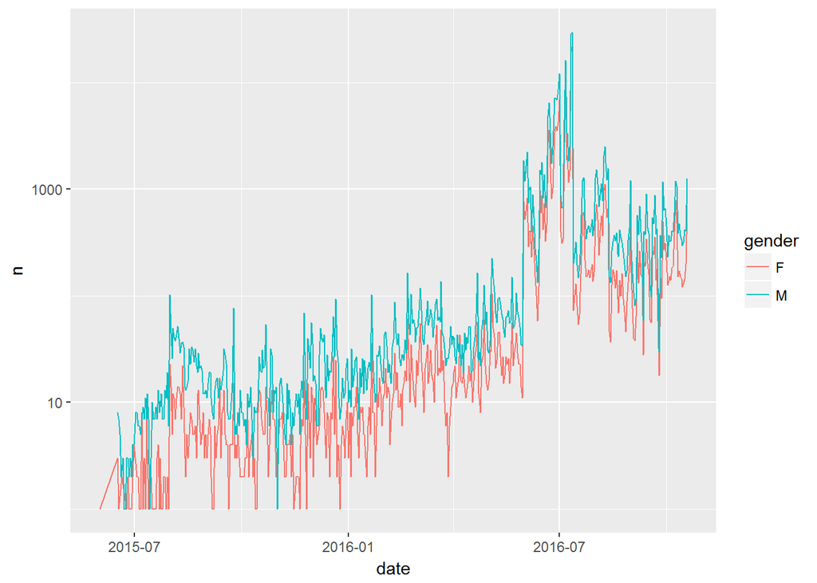

As expected, count of donations from male is almost always higher.

# Final Plots and Summary

### Plot One: total donations trend over time, by gender, and candidate

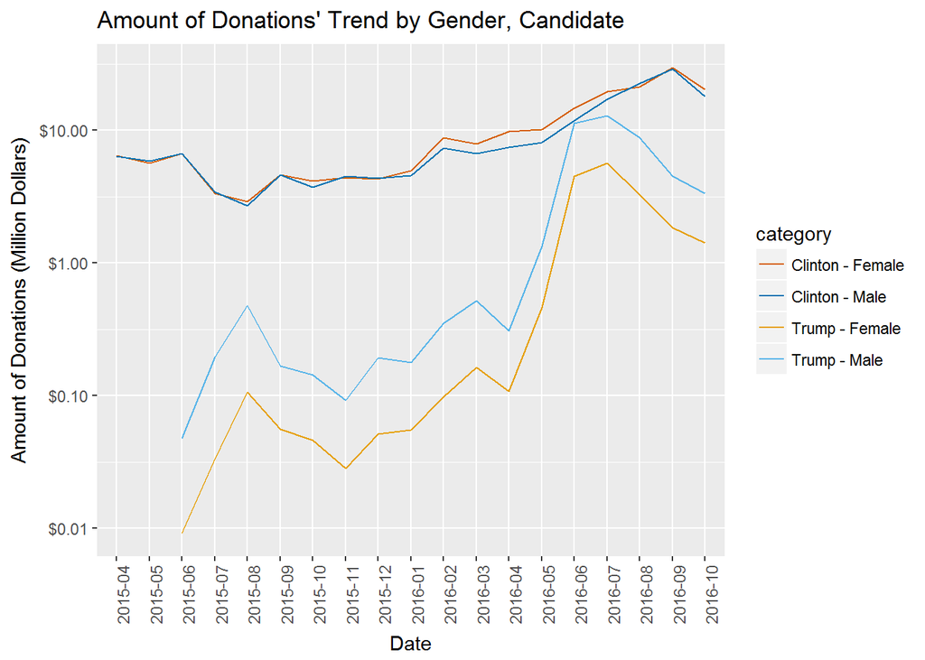

### Plot Two: Count of Donations’ Trend over Time by Gender, and Candidate

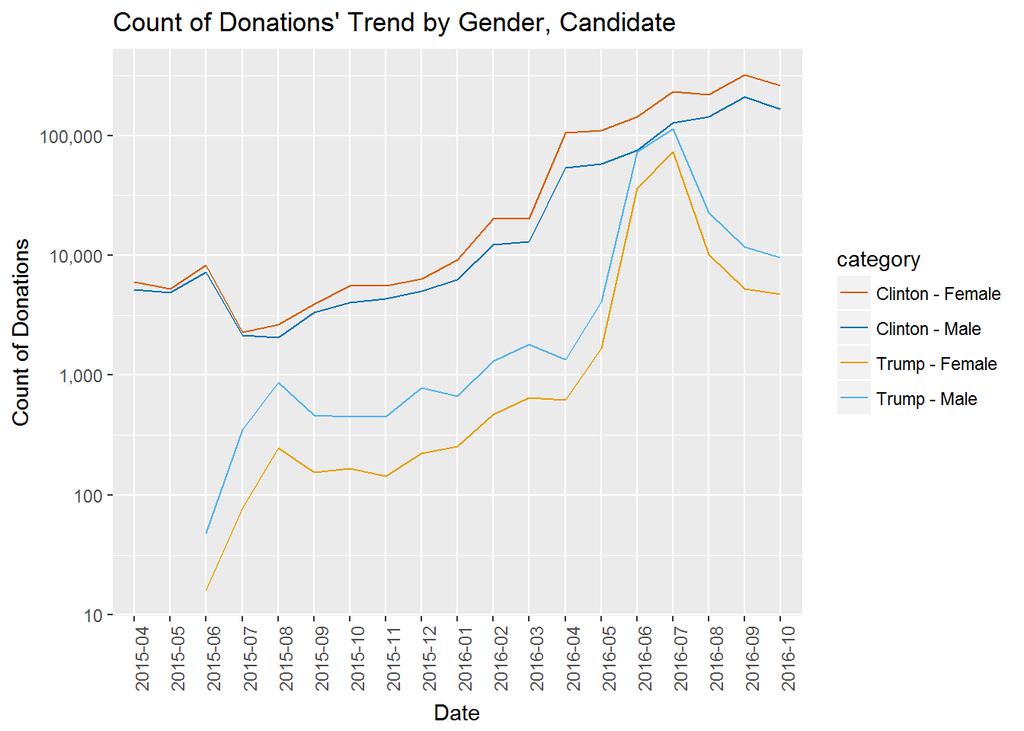

### Description Two

This graph is somewhat similar to the previous graph in terms of the overall pattern. The lines representing donations to Clinton, are more separated than the lines in the previous graph. Also, the line representing female donors to Clinton is consistently showing a higher rate.

The spike in Trumps donations stands out in this graph, too.

### Plot Three

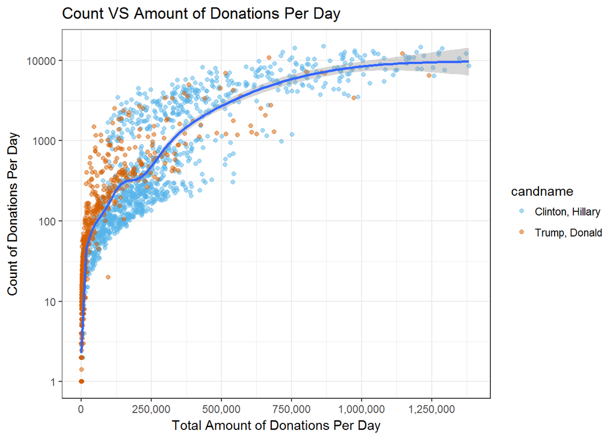

### Description Three

Each dot represents a day with its y-value being number of donations on that day as well as x-value beign total amount of contribution. As the count of donation goes up, total amount increases, but that’s no surprise as x value is basically the accumulation of money contributed. What I find insightful here is that, although Trump’s campaign raised less money, if we zoom in the < 100,000 dollars, it seems they outnumbered Clinton’s in terms of number of donations. One could argue it’s the amount of money that matters to candidates at the end of the day, but I believe how many times people donated can indicate how willing they are to help their candidate of choice win. How much money they contribute, is more dependent on how well they are doing financially. As we look at higher totals, Trump donations fade away. This suggests Clinton have attracted richer population. When we look at a specific count say, 100, we see Trump donors have a lower total. Conversely, when you look at a fixed total, say 50,000 dollars, you see Trumps donor have a higher count. This supports the previous hypothesis.

# Reflection

The spike in contribution to Trump is notable in both amount and count charts. I’m still researching about what might have caused this. From what I’ve gathered so far, it seems like he started a really successful fundraising around June in Texas.

There are two factors I tried to ephasize on: amount and count. My conclusion from these graphs is that amount is more an indicator of how successful a campaign is in raising money, whereas count can be attributed to citizens’ support for their particular choice. if a candidate has a high count of donation with a low amount (kind of like what Trump had), that means a lot of people were willing to support, and that the campaign successfully attracted the voters, but maybe the ones with lower income.

In conclusion, I think it’s important to separate count of donations from amount the better understand contributors’ behaviour, as well as campaign performance.

Although this study can give a better understanding of the dynamic of individual contributions to these campaigns, a lot more work needs to be done in order for us to draw conclusions. Firstly, these findings are not suggesting a causal relationship as that can be established by setting up an experiment only. Rather, this is an attempt to explore patterns and trends hidden in the data.

Some future step could potentially include adding in US household income data to compare it against contribution based on location. States like California and New york had the highest contributions, but would they still be if we normalized contribution using income data?

NOTE: THIS DATA WAS ACQUIRED FROM OPENSECRETS.ORG. NOT FOR COMMERCIAL USES.